# Exploratory Analysis of qPCR Data

Hannah Trautmann

May 10, 2019

## Data Collection

A more in-depth explanation of the experiment is described in the attached paper. In brief, quantitative PCR data was collected to determine enrichment of ribosomal proteins at particular genes. The values collected are termed CP, or crossing point, which represents the PCR cycle number at which each sample reached a certain threshold of fluorescence. Smaller CP values indicate higher amounts of protein at the gene because more DNA was recovered during immunoprecipitation.

The study involved two main variables: (1) treatment of cells with rifampicin or not, and (2) analysis of protein coding or non-protein coding genes. Each set of samples was compared to an input sample, collected prior to immunoprecipitation. The samples could then further be analyzed by comparing test genes to control genes, or by comparing based on treatment with rifampicin. Both comparisons were made in this exploratory analysis, to help determine which is more informative and biologically meaningful.

## Normalize to Control Gene

The first way to interpret the data is to normalize all treatments to the control gene. In this case, that is the non-protein coding gene for 23s rRNA.

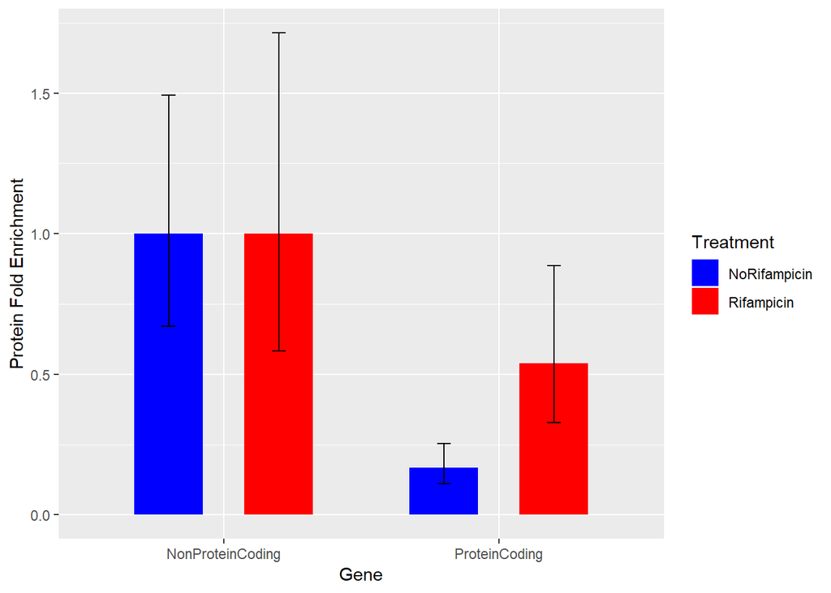

Figure 1: qPCR results normalized to non-protein coding gene. Red bars represent those treated with rifampicin, while blue bars represent control treatment. Protein coding refers to amplification of FTL_1364 and non-protein coding refers to 23s rRNA.

## Normalize to Control Treatment

The second way to analyze the data is to normalize the data to the control treatment. In this case, that is the “no rifampicin” treatment.

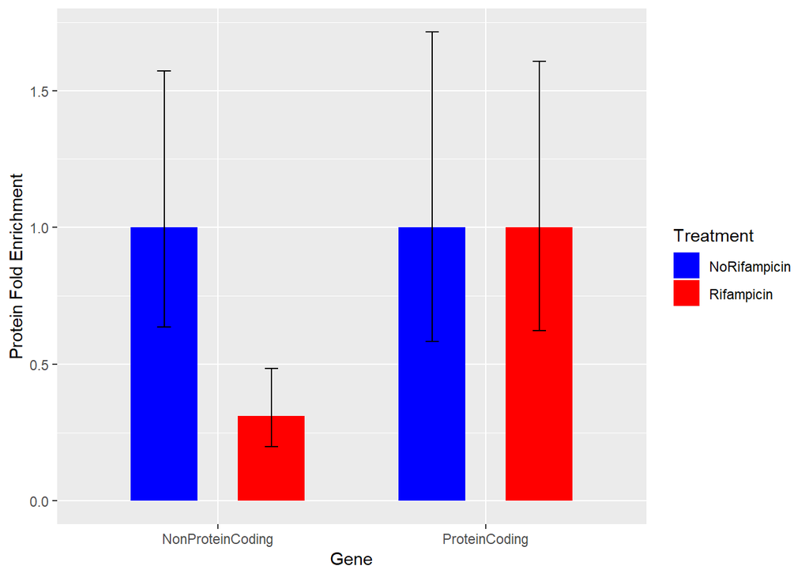

Figure 2: qPCR results normalized to control treatment, with no rifampicin added. Red bars represent those treated with rifampicin, while blue bars represent control treatment. Protein coding refers to amplification of FTL_1364 and non-protein coding refers to 23s rRNA.

In this case, it is clear that the addition of rifampicin does not have a significant impact on the protein coding gene but does appear to lead to decreased association of ribosomes at the 23s rRNA gene. These data indicate that the 23s rRNA gene is a poor control as it is affected by treatment. This tells the researchers that the control must be altered to improve the experiment, and thus the analysis in which our data is normalized to control treatment is the more meaningful approach.

## Applied to Other Data

In order to test that this R code could easily be used for other datasets, a new set of data with different controls and treatments was analyzed. In this experiment, the “treatment” was a mutation of one amino acid in the protein being analyzed (D51A PmrA-V vs. unmutated PmrA-V) and the genes were PriM (test) and tul4 (control).

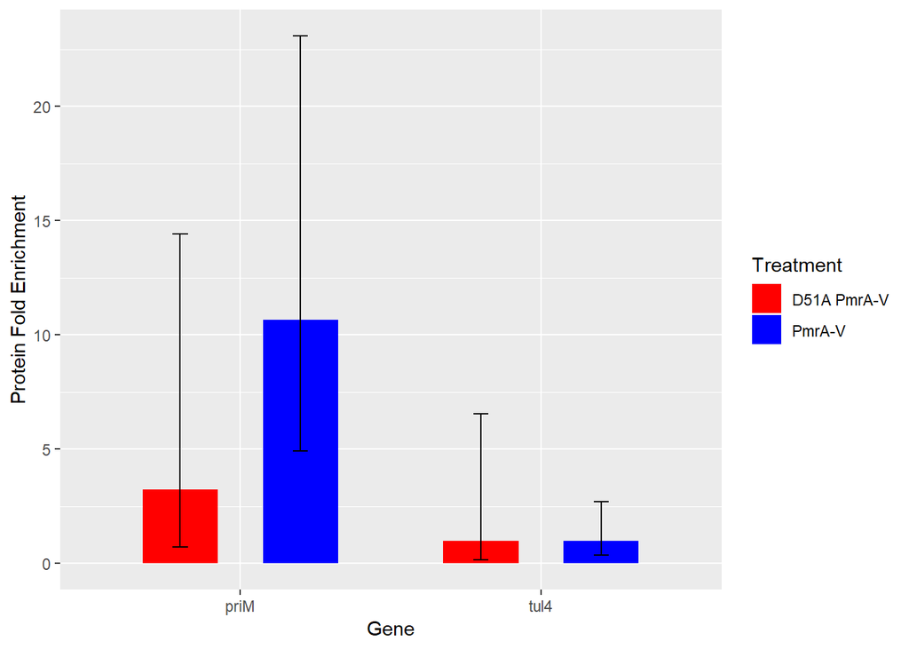

Figure 3: qPCR results of experiment 2 normalized to control gene tul4. Red bars represent mutant PmrA, while blue bars represent wild-type PmrA.